# Научная презентация 13

Дисциплина:Операционные системы

Алехин Давид Андреевич

Российский университет дружбы народов, Москва, Россия

Математический институт имени Никольского, Москва, Россия

06.03.25

# Информация

## Докладчик

- Алехин Давид Андреевич
- Студент
- Студент НММбд-01-24
- Российский университет дружбы народов
- 1132246830@pfur.ru
- https://github.com/trustdef

[figure not shown]

# Элементы презентации

## Цели и задачи

- Изучить основы программирования в оболочке ОС UNIX. Научится писать более сложные командные файлы с использованием логических управляющих конструкций и циклов.

## Материалы и методы

- fedora-linux

## Содержание исследования

Используя команды getopts grep напишем командный файл, который анализирует командную строку с ключами и выполним его: -i inputfile — прочитать данные из указанного файла; -o outputfile — вывести данные в указанный файл; -p шаблон — указать шаблон для поиска; -C — различать большие и малые буквы; -n — выдавать номера строк; а затем ищет в указанном файле нужные строки (рис. [-@fig:001], [-@fig:002]).

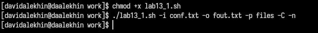

1

## Содержание исследования

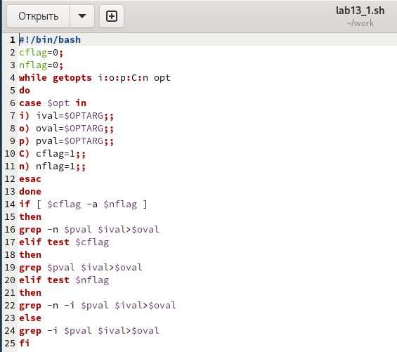

2

## Содержание исследования

Напишем сначала на языке Си программу, которая вводит число и определяет, является ли оно больше нуля, меньше нуля или равно нулю. Затем завершим программу при помощи функции exit(n), передавая информацию о коде завершения в оболочку. Командный файл вызовет эту программу и, проанализировав с помощью команды $?, выдаст сообщение о том, какое число было введено (рис. [-@fig:003], [-@fig:004], [-@fig:005] ).

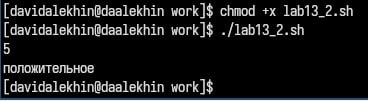

3

## Содержание исследования

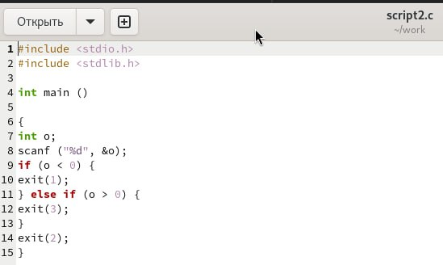

4

## Содержание исследования

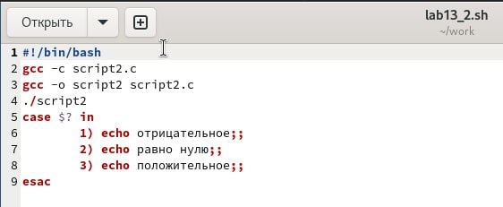

5

## Содержание исследования

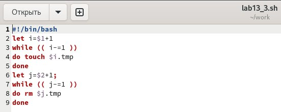

6

## Содержание исследования

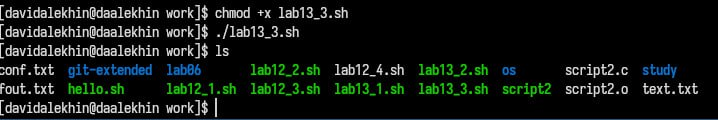

7

## Содержание исследования

Напишем командный файл, который с помощью команды tar запаковывает в архив все файлы в указанной директории. Модифицируем его так, чтобы запаковывались только те файлы, которые были изменены менее недели тому назад. (рис. [-@fig:008], [-@fig:009]).

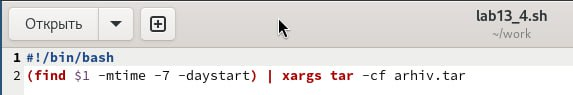

8

## Содержание исследования

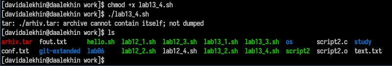

9

## Содержание исследования

## Результаты

В данной работе мы изучили основы программирования в оболочке ОС UNIX и писать более сложные командные файлы с использованием логических управляющих конструкций и циклов.

## Итоговый слайд

В теории, теория и практика неразделимы. На практике это не так. Yoggi Berra